# Assignment 3, Task 4

Catherine Takata

11/5/2020

Summary: Compare the mean size of purple urchins in CONTROL (no giant kelp removal) or ANNUAL (annual kelp removal) sections of Naples Reef in January 2010.

#### Read in data set

```r
urchins <- read.csv(here("data", "urchins.csv"))
```

#### Clean, format dates, etc - before proceeding with analysis

```r
# convert the column names to lowercase using the clean_names() of the janitor package. - will ease data analysis and calling columns
urchins_clean <- urchins %>%
  clean_names()

# in a pipe sequence, change the initial date into a different format and use mutate() function to add this new "formatted" column to the data set
# then mutate() a new column for specifically for year, in order to easily filter data
urchins_clean <- urchins_clean %>%
  mutate(date_formatted = mdy(date)) %>%
  mutate(year = year(date_formatted)) %>%
  mutate(month = month(date_formatted))

# assign the data_formatted as a "Date" class - so R knows its a value
class(urchins_clean$date_formatted)
```

```
## [1] "Date"
```

#### Begin to wrangle data, only include Naples Reef observations for purple urchins observed in January 2010

```r
naples_purp <- urchins_clean %>%
  filter(site == "NAPL",
         common_name == "Purple Urchin",
         year == "2010",
         month == "1")
```

#### Create new sample in order to isolate the observations (CONTROL + ANNUAL) for the two samples you want to compare. Utilize exploratory data vix

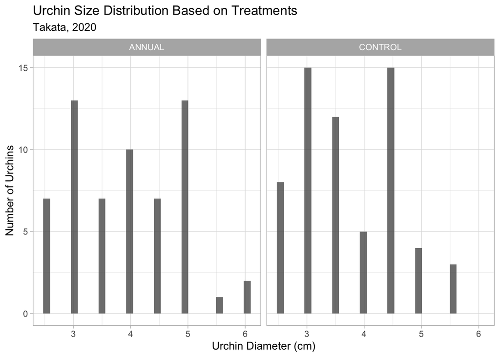

```r
ggplot(data = naples_purp, aes(x = size)) +
  geom_histogram(alpha = 0.8, show.legend = FALSE) +
  facet_wrap(~treatment) +
  labs(title = "Urchin Size Distribution Based on Treatments",
       subtitle = "Takata, 2020",
       x = "Urchin Diameter (cm)",
       y = "Number of Urchins") +
  scale_fill_manual(values = c("mediumpurple4", "firebrick3")) +
  theme_light()
```

#### Both the annual and control histograms are showing a random pattern of distribution and spread. They do not seem to follow a specific pattern or normalization curve. That being said, outliers could be skewing the dataset.

#### Quantile-quantile plot to compare my sample to nornmality, looking to see how linear that relationship is

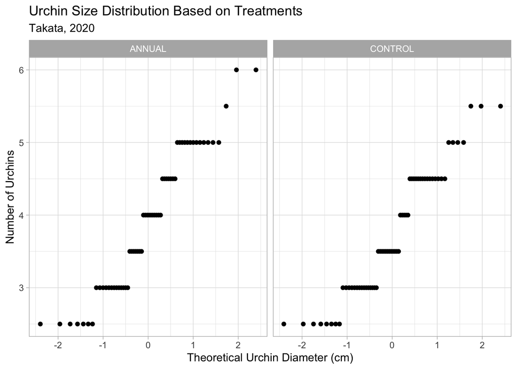

```r
ggplot(data = naples_purp, aes(sample = size)) +
  geom_qq() +
  facet_wrap(~treatment) +
  labs(title = "Urchin Size Distribution Based on Treatments",
       subtitle = "Takata, 2020",
       x = "Theoretical Urchin Diameter (cm)",
       y = "Number of Urchins") +
  scale_fill_manual(values = c("mediumpurple4", "firebrick3")) +
  theme_light()
```

#### QQ plots should display a linear relationship to reveal a normal distribution of the dataset. In this case, our data is not linear and is possibly skewed from outliers. For example, the outliers at -2 - -1 of the ANNUAL urchins could be changing the sample distribution.

## 3C - Create a table of descriptive statistics for both groups

```r
treatment_sum <- naples_purp %>%
  group_by(treatment) %>%
  summarize(mean = mean(size, na.rm = TRUE),
            sd = sd(size, na.rm = TRUE),
            n = n())

kbl(treatment_sum) %>%
  kable_styling()
```

| treatment | mean | sd | n |
| --- | --- | --- | --- |
| ANNUAL | 3.916667 | 0.9662380 | 60 |
| CONTROL | 3.725807 | 0.8668646 | 62 |

## 3D - Perform a 2 sample t-test

- Create vectors containing observations for each sample (size of urchin per treatment)

```r
control_sample <- naples_purp %>%
  filter(treatment == "CONTROL") %>%
  pull(size)

annual_sample <- naples_purp %>%
  filter(treatment == "ANNUAL") %>%
  pull(size)
```

```r
t.test(x = control_sample, annual_sample)
```

```
##
##  Welch Two Sample t-test
##
## data:  control_sample and annual_sample
## t = -1.1472, df = 117.66, p-value = 0.2536
## alternative hypothesis: true difference in means is not equal to 0
## 95 percent confidence interval:
##  -0.5203369  0.1386165
## sample estimates:
## mean of x mean of y
##  3.725806  3.916667
```

#### Through the two sample t test, we tried to determine what the probability is that our sample will have *at least* a mean difference of 0.19 - if they were pulled from a population with the same parameters (in this case, mean). If random samples are drawn from populations with the same mean, then it would be more likely to see two sample means that are close together. Based off our small mean difference, we can probabbly assume they are from a population with the same mean.

#### AFter our test, we calculated a p-value of 0.2536. From the p-value we can determine that, there is a 25% chance that these 2 samples come from the same population with at least a 0.19 mean difference. This higher p-value indcates less evidence of differences between the population means.